# Detailed Insights: Fiji

## Welcome!

You have reached the CCN Inventory Tool Detailed Insights Report.

Congratulations! This geography has available data.

Potential data availability within the Inventory Tool ranges from Tier I, Tier II, or Tier III Carbon stock estimates.

This is a downloadable document which includes country-specific insights and more detailed analysis, including carbon stocks, emissions factors, and ecosystem wetland area for mangrove, marsh, and seagrass habitats. This report details information for the selected geography, **Fiji**.

Explore the rest of the dashboard for more exciting visualizations, map features, and data.

Resources referenced to calculate Carbon stock estimates for **Fiji** are listed below ‘References’ at the end of this document.

If you have any questions or data you would like to add to the Coastal Carbon Network, please reach out to us at CoastalCarbon@si.edu.

[interactive chart not shown]

## Total Carbon Stock Estimates

Total Carbon stock estimates were calculated for each geography in total, and for mangrove, tidal marsh, and seagrass habitats, if applicable. At this time total Carbon stock estimates for each country do not include seagrass estimates due to the lack of a global, transparent, and independently assessed seagrass habitat map. However, best available areas and stocks for **Fiji** are explored in the following ‘Wetland Areas and Activities’ section.

### Country Level Total Stock Estimates

Total Geography Level Stocks

| Territory | Country | Habitat | Total Stock | Upper CI | Lower CI | Standard Error |
| --- | --- | --- | --- | --- | --- | --- |
| Fiji | Fiji | mangrove | 34172500 | 39844700 | 28500300 | 2954300 |
| Fiji | Fiji | marsh | 0 | NA | NA | NA |
| Fiji | Fiji | seagrass | 414288 | NA | NA | NA |

## Wetland Areas and Activities

### Mangrove Area

We estimate mangrove area in Fiji to be 77730 to 102600 hectares with a mean estimate of 88530 hectares according to Global Mangrove Watch, Bunting et al 2018.

### Tidal Marsh Area

We estimate tidal marsh area in Fiji to be approximately 0 hectares according to Worthington et al 2024.

### Seagrass Area

We estimate seagrass area in Fiji to have a mean estimate of 3836 hectares according to McKenzie et al 2020, which aggregates data from multiple sources.

## Calculated Stocks and Emissions Factors

This section of the report details whether data is available to estimate Tier I, Tier II, or Tier III value estimates for tidal marsh, mangrove, and seagrass ecosystems in **Fiji**.

If data for the selected country is available in the Coastal Carbon Atlas, we have applied a Tier II emission factor based on a simple average of country specific data queried from the Atlas.

IPCC Tier I Value Estimates

| Habitat | Mean | Lower CI | Upper CI |
| --- | --- | --- | --- |
| mangrove | 386 | 351 | 424 |
| marsh | 255 | 254 | 297 |
| seagrass | 108 | 84 | 139 |

### Tier I Carbon Stocks

This table includes Tier I Soil Carbon Stocks included for **Fiji**.

| Territory | Country | Habitat | Mean Stock (MgHa) | Lower CI | Upper CI |
| --- | --- | --- | --- | --- | --- |
| Fiji | Fiji | mangrove | 386 | 351 | 424 |
| Fiji | Fiji | marsh | 255 | 254 | 297 |
| Fiji | Fiji | seagrass | 108 | 84 | 139 |

### Tier II Carbon Stocks

Tier II carbon stocks were estimated, when available, from soil core data currently housed in the Coastal Carbon Atlas.

Tier II Data Availability for **Fiji**: The selected geography, **Fiji** does not currently have available Tier II carbon stock estimates at a depth of 1 meter. Please refer to Tier I values.

### Tier III Carbon Stocks

Tier III carbon stocks were estimated, when available, from remote sensing data from Maxwell et al 2021 for mangrove habitats, and Sanderman et al 2018 for tidal marsh habitats. The following details whether estimated values are available for **Fiji**, and any overlap with associated Tier I or Tier II values.

If there are no Tier III estimates associated with the selected country, please refer to Tier I and/or Tier II tables.

Tier III Data Availability for **Fiji**: There are currently no Tier III values for **Fiji** in the CCN Inventory Dashboard. Please refer to Tier I values.

## Visualizations

### 1. Data Metrics

[figure not shown]

### 2. Emissions Factors

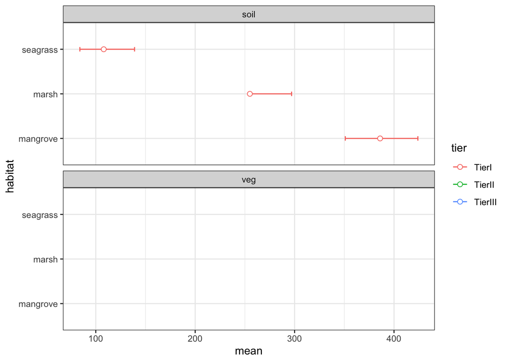

### 3. Activity Data

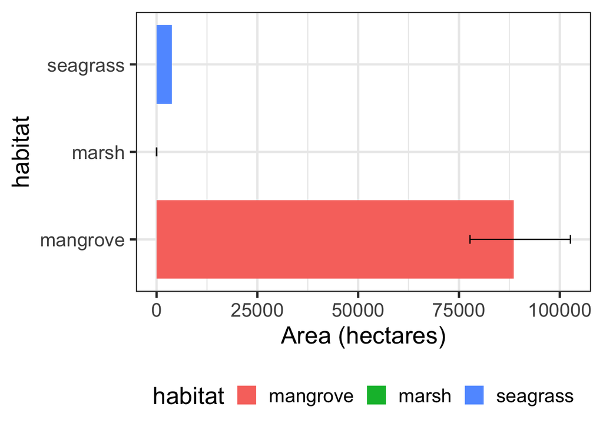

## References

Bunting, Pete, Ake Rosenqvist, Richard M. Lucas, Lisa-Maria Rebelo, Lammert Hilarides, Nathan Thomas, Andy Hardy, Takuya Itoh, Masanobu Shimada, and C. Max Finlayson. 2018. “The Global Mangrove Watch—a New 2010 Global Baseline of Mangrove Extent.” *Remote Sensing* 10 (10): 1669. https://doi.org/10.3390/rs10101669.

De Mazi‘eres, and Jeanne. 2008. “Spatial Distribution of Reef Fish Communities: An Investigation of the Coral Coast, Fiji Islands.” PhD thesis, The University of the South Pacific Suva, Fiji.

Fourqurean, James W., Carlos M. Duarte, Hilary Kennedy, NÃria Mar ‘a, Marianne Holmer, Miguel Angel Mateo, Eugenia T. Apostolaki, et al. 2012a. “Seagrass Ecosystems as a Globally Significant Carbon Stock.” *Nature Geoscience* 5 (7): 505–9. https://doi.org/10.1038/ngeo1477.

———, et al. 2012b. “Seagrass Ecosystems as a Globally Significant Carbon Stock.” *Nature Geoscience* 5 (7): 505–9. https://doi.org/10.1038/ngeo1477.

Harborne, A., Solandt, J., Afzal, D., Andrews, M., Raines, and P. 2001. “Mamanuca Coral Reef Conservation Project - Fiji (2001): Report Summary.” Coral Cay Conservation Ltd, London.

Koshy, and LP. 2001. “An Ecological and Mapping Study of the Seagrass Communities on Nukubuco Reef, Suva, Fiji.” Master of Science Thesis, School of Pure; Applied Sciences, University of the South Pacific.

McKenzie, Len J, Lina M Nordlund, Benjamin L Jones, Leanne C Cullen-Unsworth, Chris Roelfsema, and Richard K F Unsworth. 2020. “The Global Distribution of Seagrass Meadows.” *Environmental Research Letters* 15 (7): 074041. https://doi.org/10.1088/1748-9326/ab7d06.

Phinn, Stuart R., Chris M. Roelfsema, and Peter J. Mumby. 2011. “Multi-Scale, Object-Based Image Analysis for Mapping Geomorphic and Ecological Zones on Coral Reefs.” *International Journal of Remote Sensing* 33 (12): 3768–97. https://doi.org/10.1080/01431161.2011.633122.

Roelfsema, Chris. 2010. “Integrating Field Data with High Spatial Resolution Multispectral Satellite Imagery for Calibration and Validation of Coral Reef Benthic Community Maps.” *Journal of Applied Remote Sensing* 4 (1): 043527. https://doi.org/10.1117/1.3430107.

Roelfsema, Chris, Stuart Phinn, Stacy Jupiter, James Comley, and Simon Albert. 2013. “Mapping Coral Reefs at Reef to Reef-System Scales, 10s–1000s Km2, Using Object-Based Image Analysis.” *International Journal of Remote Sensing* 34 (18): 6367–88. https://doi.org/10.1080/01431161.2013.800660.

Waycott, Michelle, McKenzie, Len J, Mellors, Jane E, Ellison, et al. 2011. “Vulnerability of Mangroves, Seagrasses and Intertidal Flats in the Tropical Pacific to Climate Change.” Vulnerability of Tropical Pacific Fisheries; Aquaculture to Climate Change. Secretariat of the Pacific Community, Noumea, New Caledonia.

Worthington, Thomas A., Mark Spalding, Emily Landis, Tania L. Maxwell, Alejandro Navarro, Lindsey S. Smart, and Nicholas J. Murray. 2024. “The Distribution of Global Tidal Marshes from Earth Observation Data.” *Global Ecology and Biogeography* 33 (8). https://doi.org/10.1111/geb.13852.

Yamamuro, M, I Koike, and H Iizumi. 1993a. “Partitioning of the Nitrogen Stock in the Vicinity of a Fijian Seagrass Bed Dominated by Syringodium Isoetifolium (Ascherson) Dandy.” *Marine and Freshwater Research* 44 (1): 101. https://doi.org/10.1071/mf9930101.

———. 1993b. “Partitioning of the Nitrogen Stock in the Vicinity of a Fijian Seagrass Bed Dominated by Syringodium Isoetifolium (Ascherson) Dandy.” *Marine and Freshwater Research* 44 (1): 101. https://doi.org/10.1071/mf9930101.